# HousePriceDataAnalysis

Campos José Miguel, Herrera Franco Nahuel, Medina Milagros Fabiana - Inteligencia Empresarial y Data Mining 5K5 - Universidad Tecnológica Nacional - Facultad Regional Tucumán

03/06/2022

# **Introducción**

El dataset a trabajar contiene información de los precios de las casas de la ciudad King County del estado de Seattle, Estados Unidos. Dicha información corresponde al periodo que va desde mayo 2014 a mayo 2015. Contiene 20 variables y 21613 observaciones. La columna objetivo elegida para el análisis es “price”. Este trabajo, iniciará con el análisis exploratorio de datos, la limpieza de valores atípicos, luego se seguirá con técnicas para la selección de variables, regresión lineal y múltiple y por último clustering para agrupar observaciones con valores similares.

# **Librerías**

```r
library("dplyr")
library("corrplot")
library("moments")
library("psych")
library("dataPreparation")
library("data.table")
library("caret")
library("ggplot2")
library("lmtest")
library('mlr3data')
library("leaps")
library("fastDummies")
library("glmnet")
library("factoextra")
library("ggpubr")
library("plotmo")
```

# **Diccionario de Datos**

Para orientación del lector se realizó el siguiente diccionario de cada feature del dataset:

- `id`: Identificación única de una casa.
- `date`: Fecha en la cual la casa fue vendida.
- `bedrooms`: Número de habitaciones/Casas.
- `bathrooms`: Números de baños/Habitaciones.
- `sqft_living`: Dimensión de la casa (pies cuadrados).
- `sqft_lot`: Dimensión del lote (pies cuadrados).
- `floors`: Número total de pisos de la casa.
- `waterfront`: Si la casa tiene una vista a un espejo de agua (lago, rio, etc).
- `view`: Si la casa ha sido vista.
- `condition`: Indica la condición general de la casa. (1: la propiedad no presenta buena condición, 5: la condición de la casa es excelente).
- `grade`: Calificación general otorgada por un organismo (1: Pobre, 13: Excelente).
- `sqft_aboves`: Dimensiones de la casa aparte del sótano.
- `sqft_basement`: Dimensiones del sótano.
- `yr_built`: Año de construcción de la vivienda.
- `yr_renovated`: Año cuando la casa recibió una renovación.
- `zipcode`: Código Postal.
- `lat`: Latitud de Coordenada.
- `long`: Longitud de Coordenada.
- `sqft_living15`: Dimensiones de la sala de estar en 2015 (implica algunas renovaciones). Esto podría o no haber afectado el área del lote.
- `sqft_lot15`: Área en 2015 (implica algunas renovaciones).

# **Dataset**

## Carga

```r
raw_data_house <- mlr3data::kc_housing
```

## Directorio de Trabajo

```r
setwd(getwd())
```

## Dimensiones

```r
#Mostramos las dimensiones del dataset
dimensiones <- dim(raw_data_house)
dimensiones
```

```
[1] 21613    20
```

## Muestra

```r
head(raw_data_house,5)
```

|  | date | price | bedrooms | bathrooms | sqft_living | sqft_lot | floors | waterfront | view | condition | grade | sqft_above | sqft_basement | yr_built | yr_renovated | zipcode | lat | long | sqft_living15 | sqft_lot15 |
| --- | --- | --- | --- | --- | --- | --- | --- | --- | --- | --- | --- | --- | --- | --- | --- | --- | --- | --- | --- | --- |
| 1 | 2014-10-13 | 221900 | 3 | 1.00 | 1180 | 5650 | 1 | FALSE | 0 | 3 | 7 | 1180 | NA | 1955 | NA | 98178 | 47.5112 | -122.257 | 1340 | 5650 |
| 2 | 2014-12-09 | 538000 | 3 | 2.25 | 2570 | 7242 | 2 | FALSE | 0 | 3 | 7 | 2170 | 400 | 1951 | 1991 | 98125 | 47.7210 | -122.319 | 1690 | 7639 |
| 3 | 2015-02-25 | 180000 | 2 | 1.00 | 770 | 10000 | 1 | FALSE | 0 | 3 | 6 | 770 | NA | 1933 | NA | 98028 | 47.7379 | -122.233 | 2720 | 8062 |
| 4 | 2014-12-09 | 604000 | 4 | 3.00 | 1960 | 5000 | 1 | FALSE | 0 | 5 | 7 | 1050 | 910 | 1965 | NA | 98136 | 47.5208 | -122.393 | 1360 | 5000 |
| 5 | 2015-02-18 | 510000 | 3 | 2.00 | 1680 | 8080 | 1 | FALSE | 0 | 3 | 8 | 1680 | NA | 1987 | NA | 98074 | 47.6168 | -122.045 | 1800 | 7503 |

## Sumario

A partir del sumario podemos tener una primera aproximación de los datos. Se puede observar los mínimos valores, los máximos y las medias, entre otra información. Esto sumado a la búsqueda exhaustiva en la web sobre los posibles valores que podría tomar cada variable, además de permitirnos conocer más en profundidad las características de cada una, dieron los primeros indicios sobre dónde podrían existir los potencialmente outliers. Por ejemplo, entre la información que podemos obtener nos dice que las casas corresponden al período 2014-2015 con precios muy distantes que van desde 75000 dólares a 7.700.000. La mayoría de ellas no tienen una vista al agua. Los pisos van de 1 a 3.5 y hay casas sin habitaciones y hasta una sospechosa casa con 33 habitaciones. En cuanto a los baños, hay casas que no poseen ninguno y hay casas que tienen hasta 8 baños. El promedio en cuanto a la condición y grade nos dice que generalmente son casas regulares, que no están en sus óptimas condiciones pero que tampoco están en muy malas. A partir de observaciones realizadas en un BD se pueden advertir qué determinados valores son muy diferentes a las otras observaciones del mismo grupo de datos. Estos datos distorsionan los resultados del analisis y por esta razón debemos identificarlos y tratarlos de manera adecuada.

```r
sumario <- summary(raw_data_house)
sumario
```

```
      date                         price            bedrooms        bathrooms
 Min.   :2014-05-02 00:00:00   Min.   :  75000   Min.   : 0.000   Min.   :0.000
 1st Qu.:2014-07-22 00:00:00   1st Qu.: 321950   1st Qu.: 3.000   1st Qu.:1.750
 Median :2014-10-16 00:00:00   Median : 450000   Median : 3.000   Median :2.250
 Mean   :2014-10-29 03:58:09   Mean   : 540088   Mean   : 3.371   Mean   :2.115
 3rd Qu.:2015-02-17 00:00:00   3rd Qu.: 645000   3rd Qu.: 4.000   3rd Qu.:2.500
 Max.   :2015-05-27 00:00:00   Max.   :7700000   Max.   :33.000   Max.   :8.000

  sqft_living       sqft_lot           floors      waterfront           view
 Min.   :  290   Min.   :    520   Min.   :1.000   Mode :logical   Min.   :0.0000
 1st Qu.: 1427   1st Qu.:   5040   1st Qu.:1.000   FALSE:21450     1st Qu.:0.0000
 Median : 1910   Median :   7618   Median :1.500   TRUE :163       Median :0.0000
 Mean   : 2080   Mean   :  15107   Mean   :1.494                   Mean   :0.2343
 3rd Qu.: 2550   3rd Qu.:  10688   3rd Qu.:2.000                   3rd Qu.:0.0000
 Max.   :13540   Max.   :1651359   Max.   :3.500                   Max.   :4.0000

   condition         grade          sqft_above   sqft_basement       yr_built
 Min.   :1.000   Min.   : 1.000   Min.   : 290   Min.   :  10.0   Min.   :1900
 1st Qu.:3.000   1st Qu.: 7.000   1st Qu.:1190   1st Qu.: 450.0   1st Qu.:1951
 Median :3.000   Median : 7.000   Median :1560   Median : 700.0   Median :1975
 Mean   :3.409   Mean   : 7.657   Mean   :1788   Mean   : 742.4   Mean   :1971
 3rd Qu.:4.000   3rd Qu.: 8.000   3rd Qu.:2210   3rd Qu.: 980.0   3rd Qu.:1997
 Max.   :5.000   Max.   :13.000   Max.   :9410   Max.   :4820.0   Max.   :2015
                                                 NA's   :13126
  yr_renovated      zipcode           lat             long        sqft_living15
 Min.   :1934    Min.   :98001   Min.   :47.16   Min.   :-122.5   Min.   : 399
 1st Qu.:1987    1st Qu.:98033   1st Qu.:47.47   1st Qu.:-122.3   1st Qu.:1490
 Median :2000    Median :98065   Median :47.57   Median :-122.2   Median :1840
 Mean   :1996    Mean   :98078   Mean   :47.56   Mean   :-122.2   Mean   :1987
 3rd Qu.:2007    3rd Qu.:98118   3rd Qu.:47.68   3rd Qu.:-122.1   3rd Qu.:2360
 Max.   :2015    Max.   :98199   Max.   :47.78   Max.   :-121.3   Max.   :6210
 NA's   :20699
   sqft_lot15
 Min.   :   651
 1st Qu.:  5100
 Median :  7620
 Mean   : 12768
 3rd Qu.: 10083
 Max.   :871200
```

## Estructura

```r
#Estructura
str(raw_data_house)
```

```
'data.frame':   21613 obs. of  20 variables:
 $ date         : POSIXct, format: "2014-10-13" "2014-12-09" ...
 $ price        : num  221900 538000 180000 604000 510000 ...
 $ bedrooms     : int  3 3 2 4 3 4 3 3 3 3 ...
 $ bathrooms    : num  1 2.25 1 3 2 4.5 2.25 1.5 1 2.5 ...
 $ sqft_living  : int  1180 2570 770 1960 1680 5420 1715 1060 1780 1890 ...
 $ sqft_lot     : int  5650 7242 10000 5000 8080 101930 6819 9711 7470 6560 ...
 $ floors       : num  1 2 1 1 1 1 2 1 1 2 ...
 $ waterfront   : logi  FALSE FALSE FALSE FALSE FALSE FALSE ...
 $ view         : int  0 0 0 0 0 0 0 0 0 0 ...
 $ condition    : int  3 3 3 5 3 3 3 3 3 3 ...
 $ grade        : int  7 7 6 7 8 11 7 7 7 7 ...
 $ sqft_above   : int  1180 2170 770 1050 1680 3890 1715 1060 1050 1890 ...
 $ sqft_basement: int  NA 400 NA 910 NA 1530 NA NA 730 NA ...
 $ yr_built     : int  1955 1951 1933 1965 1987 2001 1995 1963 1960 2003 ...
 $ yr_renovated : int  NA 1991 NA NA NA NA NA NA NA NA ...
 $ zipcode      : int  98178 98125 98028 98136 98074 98053 98003 98198 98146 98038 ...
 $ lat          : num  47.5 47.7 47.7 47.5 47.6 ...
 $ long         : num  -122 -122 -122 -122 -122 ...
 $ sqft_living15: int  1340 1690 2720 1360 1800 4760 2238 1650 1780 2390 ...
 $ sqft_lot15   : int  5650 7639 8062 5000 7503 101930 6819 9711 8113 7570 ...
 - attr(*, "index")= int(0)
```

# **Análisis Exploratorio de Datos(Dataset Crudo)**

## Encontrar valores nulos

```r
#Encontrar valores nulos
data.frame(Valores.nulos = sapply(raw_data_house,function(x){sum(is.na(x))}))
```

|  | Valores.nulos |
| --- | --- |
| date | 0 |
| price | 0 |
| bedrooms | 0 |
| bathrooms | 0 |
| sqft_living | 0 |
| sqft_lot | 0 |
| floors | 0 |
| waterfront | 0 |
| view | 0 |
| condition | 0 |

[output cut: 10 more lines]

## Convertir variables con observaciónes nulas a categóricas

Convertimos las variables con observaciónes nulas a categóricas para no perder representatividad, ya que una variable(yr_renovated) al tener 20699 observaciónes nulas y el dataset tiene 21613, solo quedarían 914 observaciónes.

```r
#Convertimos las variables con observaciónes nulas a categóricas.
raw_data_house$renovated = as.numeric(!is.na(raw_data_house$yr_renovated))
raw_data_house$has_basement = as.numeric(!is.na(raw_data_house$sqft_basement))
#Eliminamos las variables con observaciónes nulas
raw_data_house$yr_renovated = NULL
raw_data_house$sqft_basement = NULL
```

## Muestra

```r
head(raw_data_house,10)
```

|  | date | price | bedrooms | bathrooms | sqft_living | sqft_lot | floors | waterfront | view | condition | grade | sqft_above | yr_built | zipcode | lat | long | sqft_living15 | sqft_lot15 | renovated | has_basement |
| --- | --- | --- | --- | --- | --- | --- | --- | --- | --- | --- | --- | --- | --- | --- | --- | --- | --- | --- | --- | --- |
| 1 | 2014-10-13 | 221900 | 3 | 1.00 | 1180 | 5650 | 1 | FALSE | 0 | 3 | 7 | 1180 | 1955 | 98178 | 47.5112 | -122.257 | 1340 | 5650 | 0 | 0 |
| 2 | 2014-12-09 | 538000 | 3 | 2.25 | 2570 | 7242 | 2 | FALSE | 0 | 3 | 7 | 2170 | 1951 | 98125 | 47.7210 | -122.319 | 1690 | 7639 | 1 | 1 |
| 3 | 2015-02-25 | 180000 | 2 | 1.00 | 770 | 10000 | 1 | FALSE | 0 | 3 | 6 | 770 | 1933 | 98028 | 47.7379 | -122.233 | 2720 | 8062 | 0 | 0 |
| 4 | 2014-12-09 | 604000 | 4 | 3.00 | 1960 | 5000 | 1 | FALSE | 0 | 5 | 7 | 1050 | 1965 | 98136 | 47.5208 | -122.393 | 1360 | 5000 | 0 | 1 |
| 5 | 2015-02-18 | 510000 | 3 | 2.00 | 1680 | 8080 | 1 | FALSE | 0 | 3 | 8 | 1680 | 1987 | 98074 | 47.6168 | -122.045 | 1800 | 7503 | 0 | 0 |
| 6 | 2014-05-12 | 1225000 | 4 | 4.50 | 5420 | 101930 | 1 | FALSE | 0 | 3 | 11 | 3890 | 2001 | 98053 | 47.6561 | -122.005 | 4760 | 101930 | 0 | 1 |
| 7 | 2014-06-27 | 257500 | 3 | 2.25 | 1715 | 6819 | 2 | FALSE | 0 | 3 | 7 | 1715 | 1995 | 98003 | 47.3097 | -122.327 | 2238 | 6819 | 0 | 0 |
| 8 | 2015-01-15 | 291850 | 3 | 1.50 | 1060 | 9711 | 1 | FALSE | 0 | 3 | 7 | 1060 | 1963 | 98198 | 47.4095 | -122.315 | 1650 | 9711 | 0 | 0 |
| 9 | 2015-04-15 | 229500 | 3 | 1.00 | 1780 | 7470 | 1 | FALSE | 0 | 3 | 7 | 1050 | 1960 | 98146 | 47.5123 | -122.337 | 1780 | 8113 | 0 | 1 |
| 10 | 2015-03-12 | 323000 | 3 | 2.50 | 1890 | 6560 | 2 | FALSE | 0 | 3 | 7 | 1890 | 2003 | 98038 | 47.3684 | -122.031 | 2390 | 7570 | 0 | 0 |

## Boxplots

Un diagrama de caja o boxplot es un método estandarizado para representar gráficamente una serie de datos numéricos a través de sus cuartiles. De esta manera, se muestran a simple vista la mediana y los cuartiles de los datos,  y también ayudan a identificar puntos de datos interesantes o atípicos. Estos últimos se representan como puntos de datos más allá de los bigotes.

### Price y Bedrooms

El boxplot de Price nos indica que el 50% de los precios de las casas van de 321950 a 645000 dólares aunque si bien la mayor cantidad de los datos se encuentran entre 75000 y 1129575. También se pueden observar una cantidad considerable de valores fuera de los límites a los cuáles a través de un análisis futuro aún más exhaustivo podremos considerarlos o no como outliers. Los precios que podrían ser potencialmente outliers entonces están entre los menores a 75000 y los mayores a 1129575.

El boxplot de Bedrooms nos muestra que el 50% de las casas tienen de 3 a 4 habitaciones aunque la mayor cantidad de casas tienen entre 1.5 y 5.5. También se pueden observar una cantidad pequeña de valores fuera de los límites los cuáles podrían ser potencialmente outliers. Cabe destacar que hay una casa que cuenta con 33 habitaciones. Este dato está muy alejado de los demás por lo que nos resulta sospechoso.

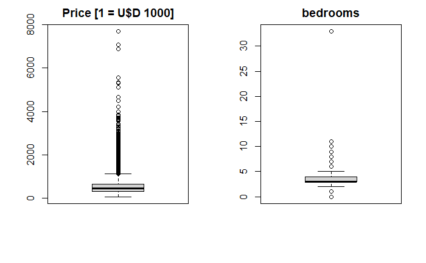

```r
par(mfrow=c(1,2))
boxplot(raw_data_house$price/1000,main="Price [1 = U$D 1000]")
boxplot(raw_data_house$bedrooms,main="bedrooms")
```

### Bathrooms

El boxplot de Bathrooms nos dice que el 50% de las casas tienen una cantidad de baños que van de 1.75 a 2.5 aunque la mayor cantidad de los datos se encuentran entre 0.6 y 3.5. También se pueden observar una cantidad pequeña de valores fuera de los límites los cuáles podrían ser potencialmente outliers.

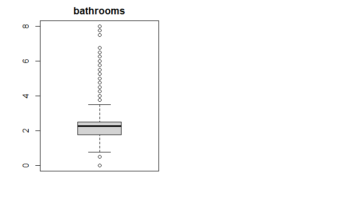

```r
par(mfrow=c(1,2))
boxplot(raw_data_house$bathrooms,main="bathrooms")
```

### Sqft_lot y Sqft_lot15

El boxplot de Sqft_lot nos dice que el 50% de los datos van de 5040 a 10688 aunque la mayor cantidad de los datos se encuentran entre 520 y 19160. También se pueden observar una cantidad considerable de valores fuera de los límites los cuáles podrían ser potencialmente outliers. El boxplot de Sqft_lot15 nos dice que el 50% de los datos van de 5100 a 10083 aunque la mayor cantidad de los datos se encuentran entre 651 y 17557. También se pueden observar una cantidad considerable de valores fuera de los límites los cuáles podrían ser potencialmente outliers. Entre ambos vemos una similitud en cuanto a las dimensiones que se manejan.

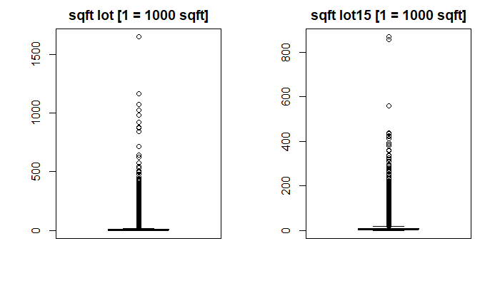

```r
par(mfrow=c(1,2))
boxplot(raw_data_house$sqft_lot/1000,main="sqft lot [1 = 1000 sqft]")
boxplot(raw_data_house$sqft_lot15/1000,main="sqft lot15 [1 = 1000 sqft]")
```

### Floors y Sqft_above

El boxplot de Floors nos dice que el 50% de las casas tienen de 1 a 2 pisos, aunque en la mayor cantidad de las casas se encuentran entre 1 y 3.5 pisos. No se observan valores fuera de los límites los cuáles podrían ser potencialmente outliers. El boxplot de sqft_above nos dice que el 50% de los datos van de 1190 a 2210 sqft aunque la mayor cantidad de los datos se encuentran entre 290 y 3740. Se observa una cantidad considerable de valores fuera de los límites los cuáles podrían ser potencialmente outliers.

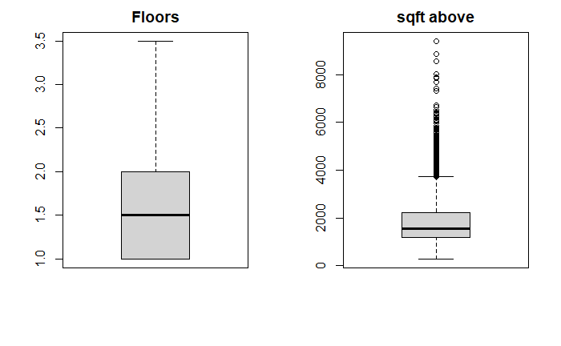

```r
par(mfrow=c(1,2))
boxplot(raw_data_house$floors,main="Floors")
boxplot(raw_data_house$sqft_above,main="sqft above")
```

### Sqft_living y Sqft_living15

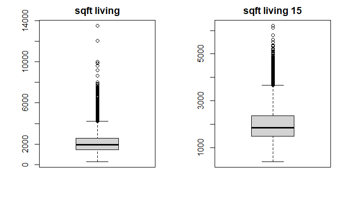

```r
par(mfrow=c(1,2))
boxplot(raw_data_house$sqft_living,main="sqft living")

boxplot(raw_data_house$sqft_living15,main="sqft living 15")
```

## Pieplots

### Renovated y Has_basement

El pie plots de renovated nos dice que casi el 96% de las casas no fueron renovadas. Es decir, solo una pequeña cantidad de las casas en estudio fueron renovadas. El pie plots de has_basement nos dice que casi el 61% de las casas no tienen sótanos.

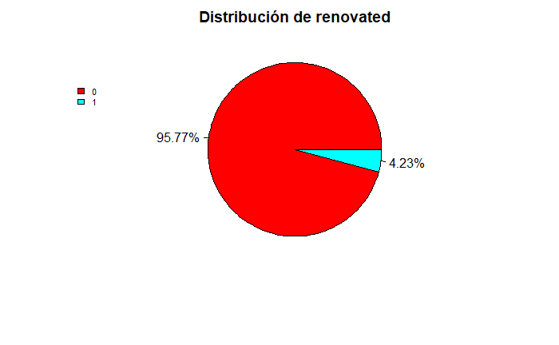

```r
workclass_1 <- table(raw_data_house$renovated)
lb = paste0(round(prop.table(workclass_1)*100,2),"%")
pie(workclass_1,labels = lb, col = rainbow(2),main="Distribución de renovated")
legend(-2.1,0.4,legend=names(workclass_1),cex=0.7,yjust=0.2, xjust = -0.1,
       fill = rainbow(2), bty = "n")
```

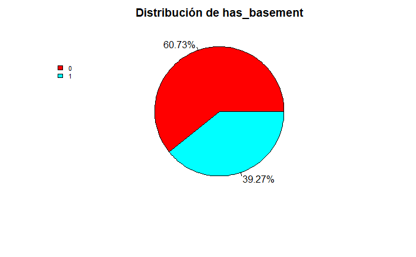

```r
workclass_2 <- table(raw_data_house$has_basement)


lb = paste0(round(prop.table(workclass_2)*100,2),"%")
pie(workclass_2,labels = lb, col = rainbow(2),main="Distribución de has_basement")
legend(-2.1,0.4,legend=names(workclass_2),cex=0.7,yjust=0.2, xjust = -0.1,
       fill = rainbow(2), bty = "n")
```

### Grade y Condition

El pie plots de grade nos dice que un poco más del 70% de las casas tienen una calificación buena/regular. El pie plots de condition nos dice que un poco más del 80% de las casas tienen una calificación buena/regular. Con estos números podemos decir que, en general, el dataset contiene casas que no están en mal estado.

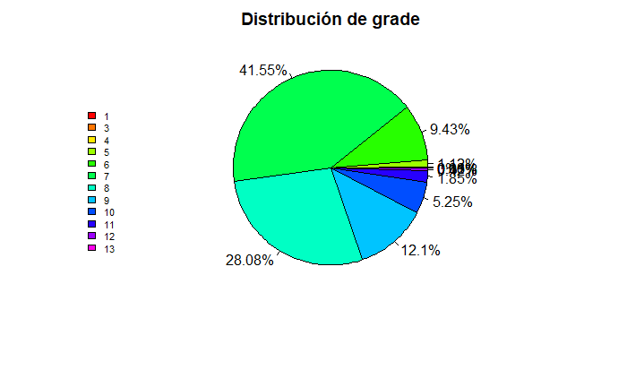

```r
workclass_3<- table(raw_data_house$grade)

lb = paste0(round(prop.table(workclass_3)*100,2),"%")
pie(workclass_3,labels = lb, col = rainbow(13),main="Distribución de grade")
legend(-2.1,0.4,legend=names(workclass_3),cex=0.7,yjust=0.9, xjust = -0.1,
       fill = rainbow(13), bty = "n")
```

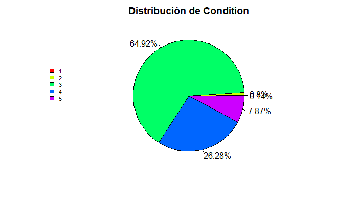

```r
workclass_4<- table(raw_data_house$condition)

lb = paste0(round(prop.table(workclass_4)*100,2),"%")
pie(workclass_4,labels = lb, col = rainbow(5),main="Distribución de Condition")
legend(-2.1,0.4,legend=names(workclass_4),cex=0.7,yjust=0.9, xjust = -0.1,
       fill = rainbow(5), bty = "n")
```

### View y Waterfront

El pie plots de view nos dice que un poco más del 90% de las casas no fueron vistas. El pie plots de waterfront nos dice que solo alrededor del 1% de las casas tienen vista al lago.

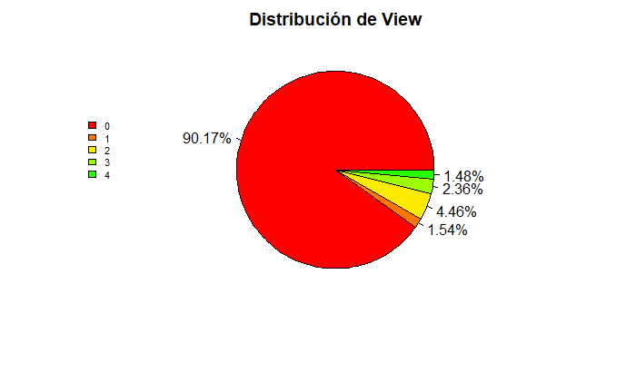

```r
workclass_5<- table(raw_data_house$view)

lb = paste0(round(prop.table(workclass_5)*100,2),"%")
pie(workclass_5,labels = lb, col = rainbow(13),main="Distribución de View")
legend(-2.1,0.4,legend=names(workclass_5),cex=0.7,yjust=0.9, xjust = -0.1,
       fill = rainbow(13), bty = "n")
```

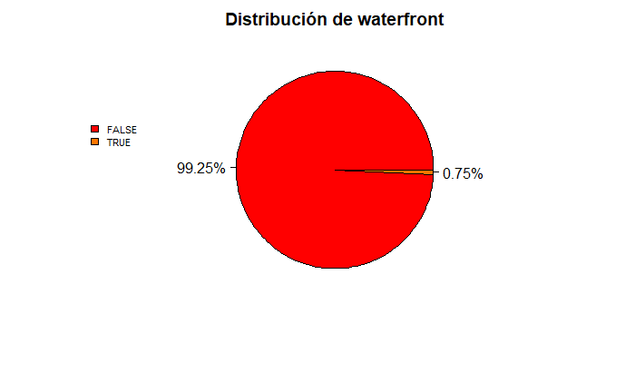

```r
workclass_6<- table(raw_data_house$waterfront)

lb = paste0(round(prop.table(workclass_6)*100,2),"%")
pie(workclass_6,labels = lb, col = rainbow(13),main="Distribución de waterfront")
legend(-2.1,0.4,legend=names(workclass_6),cex=0.7,yjust=0.9, xjust = -0.1,
       fill = rainbow(13), bty = "n")
```

## Histogramas

Un histograma es la representación gráfica en forma de barras, que simboliza la distribución de un conjunto de datos. Sirven para obtener una “primera vista” general, o panorama, de la distribución de la población, o de la muestra, respecto a una característica, cuantitativa y continua.

### Price

El histograma de Price nos muestra que, si bien la mayor cantidad de las casas cuestan hasta 2000000 de dólares, se cuenta con una alta dispersión en los precios que sospechosamente tiene una tendencia hacia la derecha. Esto nos hace pensar que algunos valores podrían interferir en el análisis por lo que a futuro se tendrá en cuenta achicar los valores de interés respecto a Price.

```r
hist(raw_data_house$price/1000,main="Histograma de Price",xlab="Price [1 = U$D 1000]",freq=F,col="gray",breaks=10)

x<-as.factor(raw_data_house$price/1000)

lines(density(raw_data_house$price/1000),col="red",lwd=2)
```

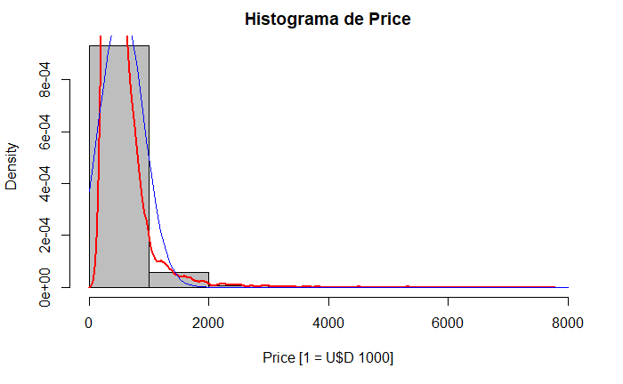

```r
curve(dnorm(x,mean=mean(raw_data_house$price/1000),sd=sd(raw_data_house$price/1000)),
      add=TRUE,
      col = "blue")
```

### Sqft_living

El histograma de Sqft_living nos muestra que, si bien la mayor cantidad de las casas cuentan con hasta un poco más de 5000 sqft de living, se cuenta con una alta dispersión en las medidas que sospechosamente tiene una tendencia hacia la derecha. Esto nos hace pensar que algunos valores podrían interferir en el análisis por lo que a futuro se tendrá en cuenta achicar los valores de interés respecto a Sqft_living.

```r
hist(raw_data_house$sqft_living,main="Histograma de sqft_living",xlab="sqft_living",freq=F,col="gray",breaks=10)

x<-as.factor(raw_data_house$sqft_living)

lines(density(raw_data_house$sqft_living),col="red",lwd=2)
```

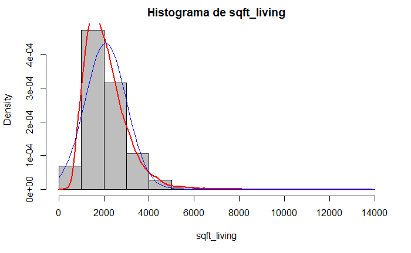

```r
curve(dnorm(x,mean=mean(raw_data_house$sqft_living),sd=sd(raw_data_house$sqft_living)),
      add=TRUE,
      col = "blue")
```

### Sqft_lot

El histograma de Sqft_lot nos muestra que, si bien la mayor cantidad de las casas cuentan con hasta un poco más de 250 sqft de lote, se cuenta con una alta dispersión en las medidas que sospechosamente tiene una tendencia hacia la derecha. Esto nos hace pensar que algunos valores podrían interferir en el análisis por lo que a futuro se tendrá en cuenta achicar los valores de interés respecto a Sqft_lote.

```r
hist(raw_data_house$sqft_lot/1000,main="Histograma de sqft_lot",xlab="sqft_lot [1 = 1000 sqft]",freq=F,col="gray",breaks=10)

x<-as.factor(raw_data_house$sqft_lot/1000)

lines(density(raw_data_house$sqft_lot/1000),col="red",lwd=2)
```

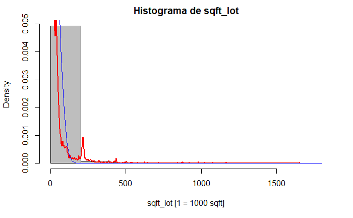

```r
curve(dnorm(x,mean=mean(raw_data_house$sqft_lot/1000),sd=sd(raw_data_house$sqft_lot/1000)),
      add=TRUE,
      col = "blue")
```

### Sqft_living15

El histograma de Sqft_living15 nos muestra que, si bien la mayor cantidad de las casas cuentan con hasta un poco más de 4000 sqft de living, se cuenta con una dispersión en las medidas que sospechosamente tiene una tendencia hacia la derecha. Esto nos hace pensar que algunos valores podrían interferir en el análisis por lo que a futuro se tendrá en cuenta achicar los valores de interés respecto a Sqft_living15.

```r
hist(raw_data_house$sqft_living15,main="Histograma de sqft_living15",xlab="sqft_living15",freq=F,col="gray",breaks=10)

x<-as.factor(raw_data_house$sqft_living15)

lines(density(raw_data_house$sqft_living15),col="red",lwd=2)
```

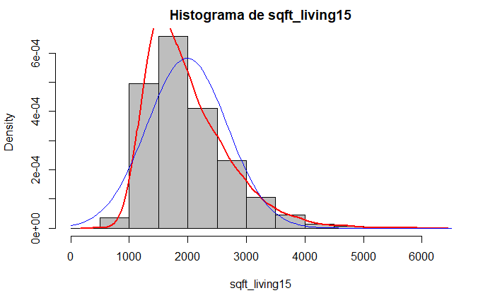

```r
curve(dnorm(x,mean=mean(raw_data_house$sqft_living15),sd=sd(raw_data_house$sqft_living15)),
      add=TRUE,
      col = "blue")
```

### Sqft_lot15

El histograma de Sqft_lot15 nos muestra que, si bien la mayor cantidad de las casas cuentan con hasta un poco más de 250 sqft de lote, se cuenta con una alta dispersión en las medidas que sospechosamente tiene una tendencia hacia la derecha. Esto nos hace pensar que algunos valores podrían interferir en el análisis por lo que a futuro se tendrá en cuenta achicar los valores de interés respecto a Sqft_lote15.

```r
hist(raw_data_house$sqft_lot15/1000,main="Histograma de sqft_lot15",xlab="sqft_lot15 [1 = 1000 sqft]",freq=F,col="gray",breaks=10)

x<-as.factor(raw_data_house$sqft_lot15/1000)

lines(density(raw_data_house$sqft_lot15/1000),col="red",lwd=2)
```

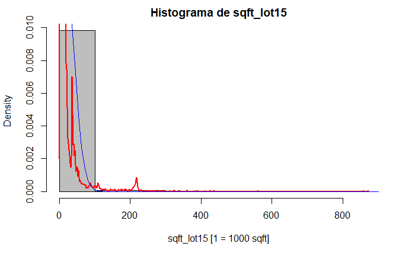

```r
curve(dnorm(x,mean=mean(raw_data_house$sqft_lot15/1000),sd=sd(raw_data_house$sqft_lot15/1000)),
      add=TRUE,
      col = "blue")
```

## Distribuciones respecto a la variable objetivo

### Price vs Bathrooms

La distribución de Price con bathrooms nos muestra que a mayor cantidad de baños las casas pueden tener un incremento en su precio. Esto se mantiene en casas que van de 1500000 con hasta 6 baños. Puede observarse que en casas con valores mayores no sigue este orden.

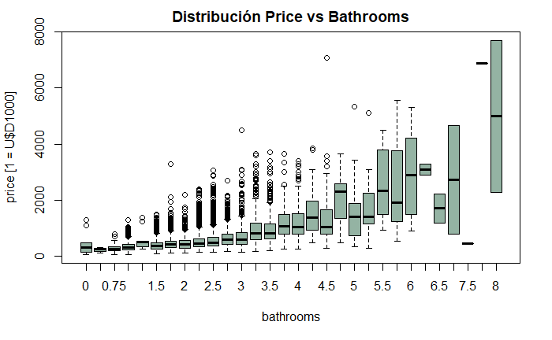

```r
boxplot(raw_data_house$price/1000 ~ raw_data_house$bathrooms , col=rgb(0.3,0.5,0.4,0.6) , ylab="price [1 = U$D1000]" ,
    xlab="bathrooms",main="Distribución Price vs Bathrooms")
```

### Price vs Bedrooms

La distribución de Price con bedrooms nos muestra que a mayor cantidad de habitaciones las casas pueden tener un incremento en su precio. Esto se mantiene en casas que van de 1500000 con hasta 6 habitaciones.

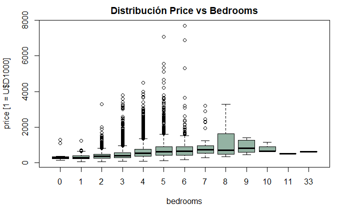

```r
boxplot(raw_data_house$price/1000 ~ raw_data_house$bedrooms , col=rgb(0.3,0.5,0.4,0.6) , ylab="price [1 = U$D1000]" ,
    xlab="bedrooms",main="Distribución Price vs Bedrooms")
```

### Price vs Sqft_living

La distribución de Price con sqft_living nos muestra que a mayor cantidad de sqft de living las casas pueden tener un leve incremento en su precio. Esto se mantiene en casas que van hasta 5000 sqft.

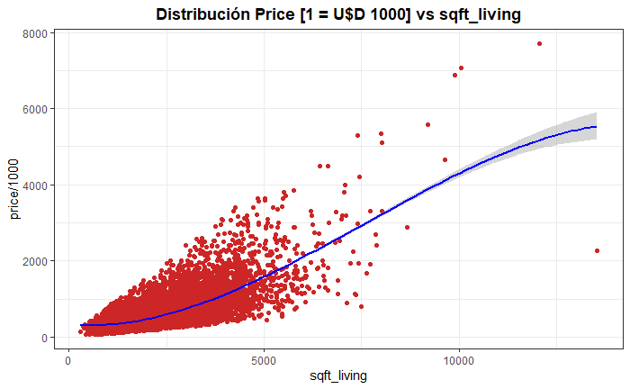

```r
ggplot(data=raw_data_house,aes(x=sqft_living,y=price/1000))+
  geom_point(colour=c("firebrick3"))+
  stat_smooth(method="lm",formula=y~poly(x,3),color="blue")+
theme_bw()+labs(title="Distribución Price [1 = U$D 1000] vs sqft_living")+
  theme(plot.title=element_text(hjust=0.5,face="bold"))
```

### Price vs Sqft_living15

La distribución de Price con sqft_living15 nos muestra que a mayor cantidad de sqft de living las casas pueden tener un muy leve incremento en su precio o mantenerse. A partir de 3000 sqft el incremento en el precio es mayor.

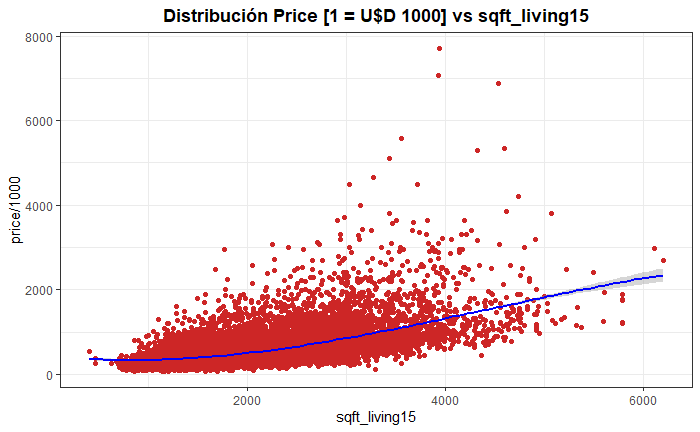

```r
ggplot(data=raw_data_house,aes(x=sqft_living15,y=price/1000))+
  geom_point(colour=c("firebrick3"))+
  stat_smooth(method="lm",formula=y~poly(x,3),color="blue")+
theme_bw()+labs(title="Distribución Price [1 = U$D 1000] vs sqft_living15")+
  theme(plot.title=element_text(hjust=0.5,face="bold"))
```

### Price vs Sqft_lot

La distribución de Price con sqft_lot y sqft_lot15 nos muestra lo contrario a las variables anteriores. Podemos ver como a valores chicos el precio puede llegar a ser alto y viceversa. A futuro podría no considerarse esta variable ya que sus los valores son sospechosos.

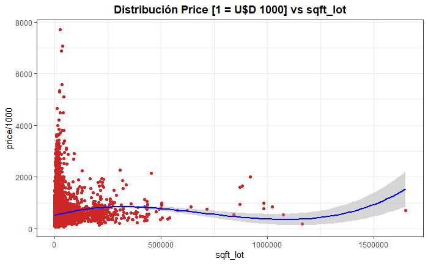

```r
ggplot(data=raw_data_house,aes(x=sqft_lot,y=price/1000))+
  geom_point(colour=c("firebrick3"))+
  stat_smooth(method="lm",formula=y~poly(x,3),color="blue")+
theme_bw()+labs(title="Distribución Price [1 = U$D 1000] vs sqft_lot")+
  theme(plot.title=element_text(hjust=0.5,face="bold"))
```

### Price vs Sqft_lot15

La distribución de Price con sqft_lot y sqft_lot15 nos muestra lo contrario a las variables anteriores. Podemos ver como a valores chicos el precio puede llegar a ser alto y viceversa. A futuro podría no considerarse esta variable ya que sus los valores son sospechosos.

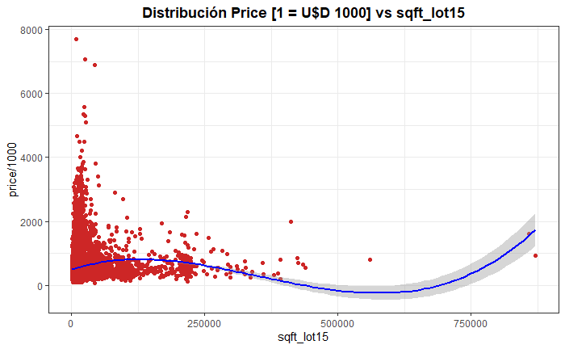

```r
ggplot(data=raw_data_house,aes(x=sqft_lot15,y=price/1000))+
  geom_point(colour=c("firebrick3"))+
  stat_smooth(method="lm",formula=y~poly(x,3),color="blue")+
theme_bw()+labs(title="Distribución Price [1 = U$D 1000] vs sqft_lot15")+
  theme(plot.title=element_text(hjust=0.5,face="bold"))
```

### Price vs Grade

La distribución de Price con grade nos muestra que a una mayor calificación las casas tienen un mayor precio. Notamos entonces que grade tiene un comportamiento ascendente en este caso.

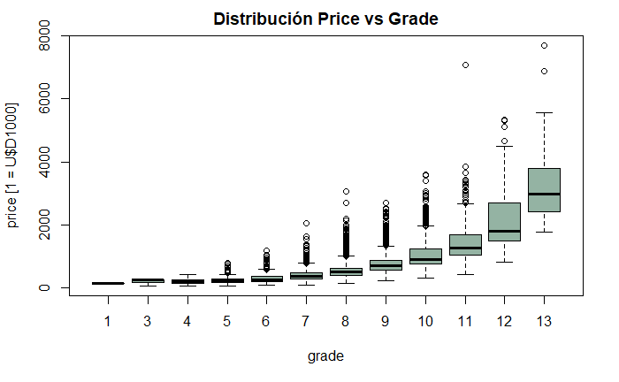

```r
boxplot(raw_data_house$price/1000 ~ raw_data_house$grade , col=rgb(0.3,0.5,0.4,0.6) , ylab="price [1 = U$D1000]" ,
    xlab="grade",main="Distribución Price vs Grade")
```

### Price vs View

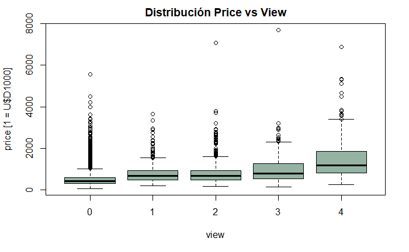

```r
boxplot(raw_data_house$price/1000 ~ raw_data_house$view , col=rgb(0.3,0.5,0.4,0.6) , ylab="price [1 = U$D1000]" ,
    xlab="view",main="Distribución Price vs View")
```

### Price vs Waterfront

La distribución de Price con waterfront nos muestra que no sigue ningún comportamiento respecto a price. Sin embargo, se puede notar que al tener una vista al lago, las casas en este caso, comienzan con un precio superior al de las casas que no poseen.

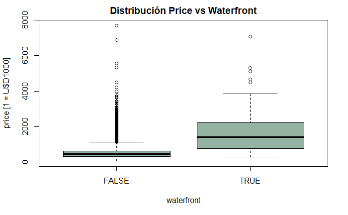

```r
boxplot(raw_data_house$price/1000 ~ raw_data_house$waterfront , col=rgb(0.3,0.5,0.4,0.6) , ylab="price [1 = U$D1000]" ,
    xlab="waterfront",main="Distribución Price vs Waterfront")
```

### Price vs Renovated

La distribución de Price con renovated nos muestra que no sigue ningún comportamiento respecto a price. Esto nos indica que renovated no es de importancia para el análisis.

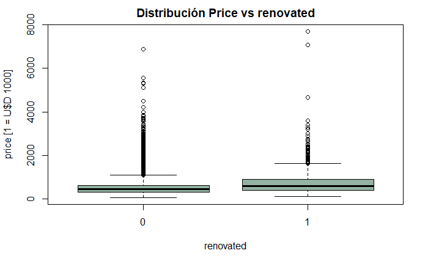

```r
boxplot(raw_data_house$price/1000 ~ raw_data_house$renovated , col=rgb(0.3,0.5,0.4,0.6) , ylab="price [1 = U$D 1000]" ,
    xlab="renovated",main="Distribución Price vs renovated")
```

### Price vs Has_basement

La distribución de Price con has_basement nos muestra que no sigue ningún comportamiento respecto a price. Sin embargo, se puede notar que las casas que si tienen sótano pueden llegar a costar aún más que las que no tienen.

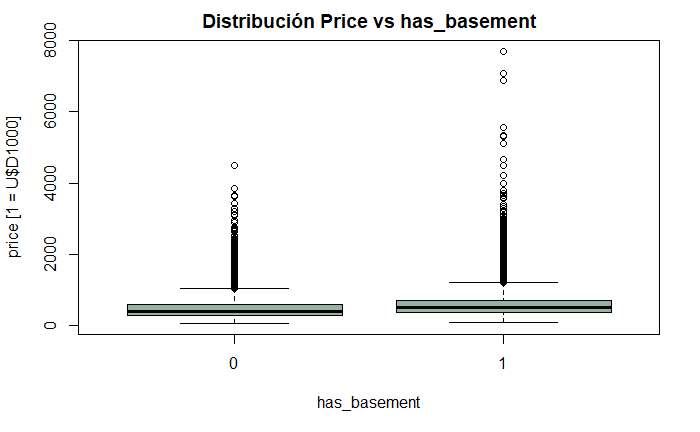

```r
boxplot(raw_data_house$price/1000 ~ raw_data_house$has_basement , col=rgb(0.3,0.5,0.4,0.6) , ylab="price [1 = U$D1000]" ,
    xlab="has_basement",main="Distribución Price vs has_basement")
```

### Price vs Sqft_above

La distribución de Price con sqft_above nos muestra que a mayor cantidad de sqft_above las casas pueden tener un leve incremento en su precio. Esto se mantiene en casas que van hasta 5000 sqft.

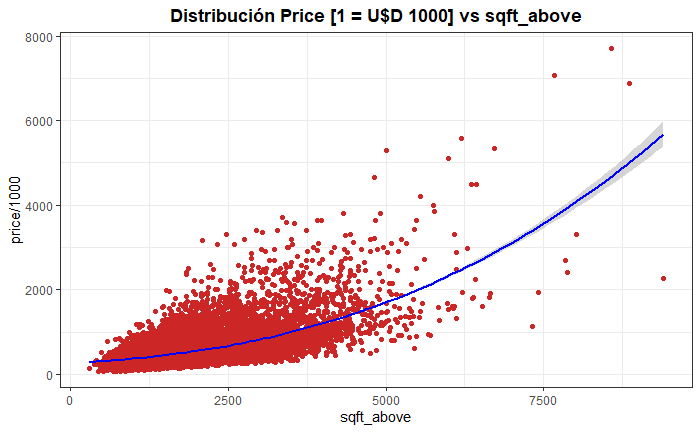

```r
ggplot(data=raw_data_house,aes(x=sqft_above,y=price/1000))+
  geom_point(colour=c("firebrick3"))+
  stat_smooth(method="lm",formula=y~poly(x,3),color="blue")+
theme_bw()+labs(title="Distribución Price [1 = U$D 1000] vs sqft_above")+
  theme(plot.title=element_text(hjust=0.5,face="bold"))
```

## Interpretación

Según el análisis realizado podemos decir que la mayoría de las casas cuestan entre 75000 y 1129575 dólares. Hay casas con valores que están alejados a estos números los cuáles a través de un análisis futuro aún más exhaustivo podremos considerarlos o no como outliers. Redondeando, vemos que la mayor cantidad de las casas cuestan hasta 2000000 de dólares, sin embargo, se cuenta con una alta dispersión en los precios que sospechosamente tiene una tendencia hacia la derecha. Esto nos hace pensar que algunos valores podrían interferir en el análisis por lo que a futuro se tendrá en cuenta achicar los valores de interés respecto a Price. En cuanto a las habitaciones la mayor cantidad de las casas tienen entre 1.5 y 5.5. Se observó que a mayor cantidad de habitaciones las casas tienen un incremento en su precio. Esto se mantiene en casas que van de u$1500000 con hasta 6 habitaciones. Con respecto a los baños, la mayoría de las casas tienen entre 0.6 y 3.5. También sucede que a mayor cantidad de baños las casas tienen un incremento en su precio. Esto se mantiene en casas que van de 1500000 con hasta 6 baños. Puede observarse que en casas valores mayores no sigue este orden. Si hablamos de sótanos, casi el 61% de las casas no tienen sótanos. Se puede notar que las casas que si tienen sótano pueden llegar a costar aún más que las que no tienen. Al hablar de dimensiones, se tienen casas mayormente de 520 a 19160 sqft tanto en sqft_lot y sqft_lot15. Sin embargo, se cuenta con una alta dispersión en las medidas que sospechosamente tiene una tendencia hacia la derecha. Esto nos hace pensar que algunos valores podrían interferir en el análisis por lo que a futuro se tendrá en cuenta achicar los valores de interés respecto a Sqft_lote. Respecto al precio y sus dimensiones (sqft_lot y sqft_lot15) nos muestra lo contrario a las variables anteriores. Podemos ver como a valores chicos el precio puede llegar a ser alto y viceversa. A futuro podría no considerarse esta variable ya que sus los valores son sospechosos. Respecto a las dimensiones sin contar las del sótano, se encuentran casas con entre 290 y 3740 sqft mayormente. Se observa que a mayor cantidad de sqft las casas pueden tener un leve incremento en su precio. Esto se mantiene en casas que van hasta 5000 sqft. Se tiene entre 290 y 4234 sqft de living principalmente. Si bien la mayor cantidad de las casas cuentan con hasta 5000 sqft de living, se cuenta con una alta dispersión en las medidas que sospechosamente tiene una tendencia hacia la derecha. Esto nos hace pensar que algunos valores podrían interferir en el análisis por lo que a futuro se tendrá en cuenta achicar los valores de interés respecto a Sqft_living. A mayor cantidad de sqft de living las casas pueden tener un leve incremento en su precio. Esto se mantiene en casas que van hasta 5000 sqft. Lo mismo sucede con Sqft_living15. La diferencia está en que sqft_living15 nos muestra que a mayor cantidad de sqft de living las casas pueden tener un muy leve incremento en su precio o mantenerse pero que a partir de 3000 sqft el incremento en el precio es mayor. Si hablamos de renovación, casi el 96% de las casas no pasaron por ello. Las casas en su mayoría (un poco más del 70%) tienen una calificación buena/regular y se observó que a una mayor calificación las casas tienen un mayor precio. Notamos que grade tiene un comportamiento ascendente en este caso. Si nos remitimos a las condiciones de las mismas hay una similitud ya que un poco más del 80% de las casas tienen una calificación buena/regular. Alrededor del 99% de las casas no tienen una vista al lago.Sin embargo, se puede notar que al tener una vista al lago, las casas en este caso, comienzan con un precio superior al de las casas que no poseen. Un poco más del 90% de las casas no fueron vistas.

# **Dataset con Factores**

## Creacion

Creamos el dataset de los factores para tener una idea general de los valores del mismo.

```r
#Convertir en factores
deleteme <- raw_data_house
deleteme$price<-as.factor(raw_data_house$price)
deleteme$bedrooms<-as.factor(raw_data_house$bedrooms)
deleteme$bathrooms<-as.factor(raw_data_house$bathrooms)
deleteme$sqft_living<-as.factor(raw_data_house$sqft_living)
deleteme$sqft_lot<-as.factor(raw_data_house$sqft_lot)
deleteme$floors<-as.factor(raw_data_house$floors)
deleteme$waterfront<-as.factor(raw_data_house$waterfront)
deleteme$view<-as.factor(raw_data_house$view)
deleteme$condition<-as.factor(raw_data_house$condition)
deleteme$grade<-as.factor(raw_data_house$grade)
deleteme$sqft_above<-as.factor(raw_data_house$sqft_above)
deleteme$has_basement<-as.factor(raw_data_house$has_basement)
deleteme$renovated<-as.factor(raw_data_house$renovated)
deleteme$yr_built<-as.factor(raw_data_house$yr_built)
deleteme$zipcode<-as.factor(raw_data_house$zipcode)
deleteme$lat<-as.factor(raw_data_house$lat)
deleteme$long<-as.factor(raw_data_house$long)
deleteme$sqft_living15<-as.factor(raw_data_house$sqft_living15)
deleteme$sqft_lot15<-as.factor(raw_data_house$sqft_lot15)
```

## Estructura

```r
estructura_factores <- str(deleteme)
```

```
'data.frame':   21613 obs. of  20 variables:
 $ date         : POSIXct, format: "2014-10-13" "2014-12-09" ...
 $ price        : Factor w/ 4028 levels "75000","78000",..: 350 2092 181 2374 1968 3603 537 756 390 946 ...
 $ bedrooms     : Factor w/ 13 levels "0","1","2","3",..: 4 4 3 5 4 5 4 4 4 4 ...
 $ bathrooms    : Factor w/ 30 levels "0","0.5","0.75",..: 4 9 4 12 8 18 9 6 4 10 ...
 $ sqft_living  : Factor w/ 1038 levels "290","370","380",..: 110 507 40 317 239 931 245 83 265 298 ...
 $ sqft_lot     : Factor w/ 9782 levels "520","572","600",..: 2536 3579 5521 2126 4210 9434 3283 5332 3752 3115 ...
 $ floors       : Factor w/ 6 levels "1","1.5","2",..: 1 3 1 1 1 1 3 1 1 3 ...
 $ waterfront   : Factor w/ 2 levels "FALSE","TRUE": 1 1 1 1 1 1 1 1 1 1 ...
 $ view         : Factor w/ 5 levels "0","1","2","3",..: 1 1 1 1 1 1 1 1 1 1 ...
 $ condition    : Factor w/ 5 levels "1","2","3","4",..: 3 3 3 5 3 3 3 3 3 3 ...
 $ grade        : Factor w/ 12 levels "1","3","4","5",..: 6 6 5 6 7 10 6 6 6 6 ...
 $ sqft_above   : Factor w/ 946 levels "290","370","380",..: 124 396 41 90 256 766 262 91 90 314 ...
 $ yr_built     : Factor w/ 116 levels "1900","1901",..: 56 52 34 66 88 102 96 64 61 104 ...
 $ zipcode      : Factor w/ 70 levels "98001","98002",..: 67 56 17 59 38 30 3 69 61 24 ...
 $ lat          : Factor w/ 5034 levels "47.1559","47.1593",..: 2399 4479 4648 2493 3440 3832 562 1464 2410 1102 ...
 $ long         : Factor w/ 752 levels "-122.519","-122.515",..: 224 162 248 88 436 476 154 166 144 450 ...
 $ sqft_living15: Factor w/ 777 levels "399","460","620",..: 110 209 492 117 236 748 354 199 231 397 ...
 $ sqft_lot15   : Factor w/ 8689 levels "651","659","660",..: 2165 3471 3805 1749 3358 8460 2895 4961 3849 3413 ...
 $ renovated    : Factor w/ 2 levels "0","1": 1 2 1 1 1 1 1 1 1 1 ...
 $ has_basement : Factor w/ 2 levels "0","1": 1 2 1 2 1 2 1 1 2 1 ...
 - attr(*, "index")= int(0)
```

```r
estructura_factores
```

## Sumario

```r
sumario_factores <- summary(deleteme)
sumario_factores
```

```
      date                         price          bedrooms      bathrooms
 Min.   :2014-05-02 00:00:00   350000 :  172   3      :9824   2.5    :5380
 1st Qu.:2014-07-22 00:00:00   450000 :  172   4      :6882   1      :3852
 Median :2014-10-16 00:00:00   550000 :  159   2      :2760   1.75   :3048
 Mean   :2014-10-29 03:58:09   5e+05  :  152   5      :1601   2.25   :2047
 3rd Qu.:2015-02-17 00:00:00   425000 :  150   6      : 272   2      :1930
 Max.   :2015-05-27 00:00:00   325000 :  148   1      : 199   1.5    :1446
                               (Other):20660   (Other):  75   (Other):3910
  sqft_living       sqft_lot     floors      waterfront    view      condition
 1300   :  138   5000   :  358   1  :10680   FALSE:21450   0:19489   1:   30
 1400   :  135   6000   :  290   1.5: 1910   TRUE :  163   1:  332   2:  172
 1440   :  133   4000   :  251   2  : 8241                 2:  963   3:14031
 1010   :  129   7200   :  220   2.5:  161                 3:  510   4: 5679
 1660   :  129   4800   :  120   3  :  613                 4:  319   5: 1701
 1800   :  129   7500   :  119   3.5:    8
 (Other):20820   (Other):20255
     grade        sqft_above       yr_built        zipcode           lat
 7      :8981   1300   :  212   2014   :  559   98103  :  602   47.5322:   17
 8      :6068   1010   :  210   2006   :  454   98038  :  590   47.5491:   17
 9      :2615   1200   :  206   2005   :  450   98115  :  583   47.6624:   17
 6      :2038   1220   :  192   2004   :  433   98052  :  574   47.6846:   17
 10     :1134   1140   :  184   2003   :  422   98117  :  553   47.6711:   16
 11     : 399   1400   :  180   1977   :  417   98042  :  548   47.6886:   16
 (Other): 378   (Other):20429   (Other):18878   (Other):18163   (Other):21513
       long       sqft_living15     sqft_lot15    renovated has_basement
 -122.29 :  116   1540   :  197   5000   :  427   0:20699   0:13126
 -122.3  :  111   1440   :  195   4000   :  357   1:  914   1: 8487
 -122.362:  104   1560   :  192   6000   :  289
 -122.291:  100   1500   :  181   7200   :  211
 -122.372:   99   1460   :  169   4800   :  145
 -122.363:   99   1580   :  167   7500   :  142
 (Other) :20984   (Other):20512   (Other):20042
```

## Eliminar

Eliminamos el dataset de factores porqué era para tener conocimiento de las variables únicamente.

```r
rm(deleteme)
```

# **Matriz de Correlación**

La correlación es una medida estadística que expresa hasta qué punto dos variables están relacionadas linealmente. Es una herramienta común para describir relaciones simples sin hacer afirmaciones sobre causa y efecto. La matriz de correlación muestra los valores de correlación de Pearson, que miden el grado de relación lineal entre cada par de elementos o variables. A menudo, las variables con valores de correlación mayores que 0.7 se consideran altamente correlacionadas.

## Matriz de correlación con variable objetivo

```r
raw_data_with_price <- raw_data_house
raw_data_with_price$date = NULL
data_correlation_with_price<- cor(raw_data_with_price)
data_correlation_with_price
```

```
                    price     bedrooms   bathrooms sqft_living     sqft_lot
price          1.00000000  0.308349598  0.52513751  0.70203505  0.089660861
bedrooms       0.30834960  1.000000000  0.51588364  0.57667069  0.031703243
bathrooms      0.52513751  0.515883638  1.00000000  0.75466528  0.087739662
sqft_living    0.70203505  0.576670693  0.75466528  1.00000000  0.172825661
sqft_lot       0.08966086  0.031703243  0.08773966  0.17282566  1.000000000
floors         0.25679389  0.175428935  0.50065317  0.35394929 -0.005200991
waterfront     0.26636943 -0.006582479  0.06374363  0.10381782  0.021603683
view           0.39729349  0.079531852  0.18773702  0.28461119  0.074710106
condition      0.03636179  0.028472104 -0.12498193 -0.05875259 -0.008958250
grade          0.66743426  0.356966725  0.66498253  0.76270448  0.113621124
sqft_above     0.60556730  0.477600161  0.68534248  0.87659660  0.183512281
yr_built       0.05401153  0.154178069  0.50601944  0.31804877  0.053080367
zipcode       -0.05320285 -0.152668487 -0.20386627 -0.19943004 -0.129574486
lat            0.30700348 -0.008931010  0.02457295  0.05252946 -0.085682788
long           0.02162624  0.129472975  0.22304184  0.24022330  0.229520859
sqft_living15  0.58537890  0.391637524  0.56863429  0.75642026  0.144608174
sqft_lot15     0.08244715  0.029244224  0.08717536  0.18328555  0.718556752
renovated      0.12609226  0.018552632  0.05026007  0.05509380  0.007745267
has_basement   0.18023009  0.163470686  0.16353417  0.20449501 -0.035345763
                    floors   waterfront         view    condition       grade
price          0.256793888  0.266369434  0.397293488  0.036361789  0.66743426
bedrooms       0.175428935 -0.006582479  0.079531852  0.028472104  0.35696673
bathrooms      0.500653173  0.063743629  0.187737024 -0.124981933  0.66498253
sqft_living    0.353949290  0.103817818  0.284611186 -0.058752587  0.76270448
sqft_lot      -0.005200991  0.021603683  0.074710106 -0.008958250  0.11362112
floors         1.000000000  0.023698320  0.029443820 -0.263767946  0.45818251
waterfront     0.023698320  1.000000000  0.401857351  0.016653157  0.08277491
view           0.029443820  0.401857351  1.000000000  0.045989737  0.25132058
condition     -0.263767946  0.016653157  0.045989737  1.000000000 -0.14467367
grade          0.458182514  0.082774914  0.251320585 -0.144673671  1.00000000
sqft_above     0.523884710  0.072074592  0.167649344 -0.158213616  0.75592294
yr_built       0.489319425 -0.026161086 -0.053439851 -0.361416562  0.44696320
zipcode       -0.059120642  0.030284728  0.084826917  0.003025524 -0.18486209
lat            0.049614131 -0.014273776  0.006156732 -0.014941006  0.11408406
long           0.125419028 -0.041910200 -0.078399712 -0.106500448  0.19837215
sqft_living15  0.279885265  0.086463136  0.280439082 -0.092824268  0.71320209
sqft_lot15    -0.011269187  0.030703283  0.072574568 -0.003405523  0.11924790
renovated      0.006259531  0.093293522  0.104061722 -0.060139481  0.01400801
has_basement  -0.256559908  0.037226752  0.181808083  0.135577306  0.05183816
```

[output cut: 25 more lines]

```
sqft_lot        0.144608174  0.718556752  0.007745267  -0.03534576
floors          0.279885265 -0.011269187  0.006259531  -0.25655991
waterfront      0.086463136  0.030703283  0.093293522   0.03722675
view            0.280439082  0.072574568  0.104061722   0.18180808
condition      -0.092824268 -0.003405523 -0.060139481   0.13557731
grade           0.713202093  0.119247897  0.014008013   0.05183816
sqft_above      0.731870292  0.194049862  0.023178311  -0.21099066
yr_built        0.326228900  0.070957926 -0.225194732  -0.16790154
zipcode        -0.279032997 -0.147221069  0.064335109   0.16296750
lat             0.048857932 -0.086418807  0.029349537   0.13850741
long            0.334604984  0.254451288 -0.068378110  -0.23718532
sqft_living15   1.000000000  0.183191749 -0.002755353   0.04382981
sqft_lot15      0.183191749  1.000000000  0.007920409  -0.04073278
renovated      -0.002755353  0.007920409  1.000000000   0.04900425
has_basement    0.043829813 -0.040732779  0.049004247   1.00000000
```

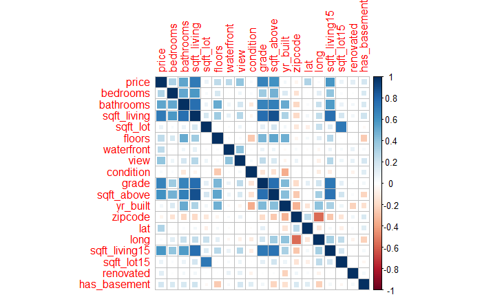

```r
corrplot(data_correlation_with_price,method="square")
```

## Matriz de correlación sin variable objetivo

```r
raw_data_without_price <- raw_data_house
raw_data_without_price$date = NULL
raw_data_without_price$price = NULL
data_correlation_without_price<- cor(raw_data_without_price)
data_correlation_without_price
```

```
                  bedrooms   bathrooms sqft_living     sqft_lot       floors
bedrooms       1.000000000  0.51588364  0.57667069  0.031703243  0.175428935
bathrooms      0.515883638  1.00000000  0.75466528  0.087739662  0.500653173
sqft_living    0.576670693  0.75466528  1.00000000  0.172825661  0.353949290
sqft_lot       0.031703243  0.08773966  0.17282566  1.000000000 -0.005200991
floors         0.175428935  0.50065317  0.35394929 -0.005200991  1.000000000
waterfront    -0.006582479  0.06374363  0.10381782  0.021603683  0.023698320
view           0.079531852  0.18773702  0.28461119  0.074710106  0.029443820
condition      0.028472104 -0.12498193 -0.05875259 -0.008958250 -0.263767946
grade          0.356966725  0.66498253  0.76270448  0.113621124  0.458182514
sqft_above     0.477600161  0.68534248  0.87659660  0.183512281  0.523884710
yr_built       0.154178069  0.50601944  0.31804877  0.053080367  0.489319425
zipcode       -0.152668487 -0.20386627 -0.19943004 -0.129574486 -0.059120642
lat           -0.008931010  0.02457295  0.05252946 -0.085682788  0.049614131
long           0.129472975  0.22304184  0.24022330  0.229520859  0.125419028
sqft_living15  0.391637524  0.56863429  0.75642026  0.144608174  0.279885265
sqft_lot15     0.029244224  0.08717536  0.18328555  0.718556752 -0.011269187
renovated      0.018552632  0.05026007  0.05509380  0.007745267  0.006259531
has_basement   0.163470686  0.16353417  0.20449501 -0.035345763 -0.256559908
                waterfront         view    condition       grade    sqft_above
bedrooms      -0.006582479  0.079531852  0.028472104  0.35696673  0.4776001614
bathrooms      0.063743629  0.187737024 -0.124981933  0.66498253  0.6853424759
sqft_living    0.103817818  0.284611186 -0.058752587  0.76270448  0.8765965987
sqft_lot       0.021603683  0.074710106 -0.008958250  0.11362112  0.1835122809
floors         0.023698320  0.029443820 -0.263767946  0.45818251  0.5238847103
waterfront     1.000000000  0.401857351  0.016653157  0.08277491  0.0720745917
view           0.401857351  1.000000000  0.045989737  0.25132058  0.1676493441
condition      0.016653157  0.045989737  1.000000000 -0.14467367 -0.1582136164
grade          0.082774914  0.251320585 -0.144673671  1.00000000  0.7559229376
sqft_above     0.072074592  0.167649344 -0.158213616  0.75592294  1.0000000000
yr_built      -0.026161086 -0.053439851 -0.361416562  0.44696320  0.4238983517
zipcode        0.030284728  0.084826917  0.003025524 -0.18486209 -0.2611899765
lat           -0.014273776  0.006156732 -0.014941006  0.11408406 -0.0008164986
long          -0.041910200 -0.078399712 -0.106500448  0.19837215  0.3438030175
sqft_living15  0.086463136  0.280439082 -0.092824268  0.71320209  0.7318702924
sqft_lot15     0.030703283  0.072574568 -0.003405523  0.11924790  0.1940498619
renovated      0.093293522  0.104061722 -0.060139481  0.01400801  0.0231783110
has_basement   0.037226752  0.181808083  0.135577306  0.05183816 -0.2109906554
                 yr_built      zipcode           lat        long sqft_living15
bedrooms       0.15417807 -0.152668487 -0.0089310097  0.12947298   0.391637524
```

[output cut: 21 more lines]

```
sqft_lot       0.718556752  0.007745267  -0.03534576
floors        -0.011269187  0.006259531  -0.25655991
waterfront     0.030703283  0.093293522   0.03722675
view           0.072574568  0.104061722   0.18180808
condition     -0.003405523 -0.060139481   0.13557731
grade          0.119247897  0.014008013   0.05183816
sqft_above     0.194049862  0.023178311  -0.21099066
yr_built       0.070957926 -0.225194732  -0.16790154
zipcode       -0.147221069  0.064335109   0.16296750
lat           -0.086418807  0.029349537   0.13850741
long           0.254451288 -0.068378110  -0.23718532
sqft_living15  0.183191749 -0.002755353   0.04382981
sqft_lot15     1.000000000  0.007920409  -0.04073278
renovated      0.007920409  1.000000000   0.04900425
has_basement  -0.040732779  0.049004247   1.00000000
```

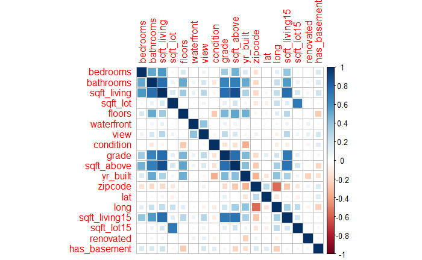

```r
corrplot(data_correlation_without_price,method="square")
```

# **Limpieza**

```r
dataset <- raw_data_house
dataset[15871,]$bedrooms=3
dataset <- filter(dataset,!(price>850000))
dataset <- filter(dataset,!(sqft_living>3200))
dataset <- filter(dataset,!(sqft_living15<600))
dataset <- filter(dataset,!(sqft_living15>2850))
dataset <- filter(dataset,!(sqft_lot>12000))
dataset <- filter(dataset,!(sqft_lot15>13000))
dataset <- filter(dataset,!(sqft_above>2700))
dataset <- filter(dataset,!(bedrooms<2))
dataset <- filter(dataset,!(bedrooms>5))
dataset <- filter(dataset,!(bathrooms<0.51))
dataset <- filter(dataset,!(bathrooms>3.74))
```

# **Dataset Limpio**

Con la limpieza de 21613 observaciónes, nos quedamos con 13865. Lo que significa una perdida del 35% de los datos.

```r
dimensiones_clean <- dim(dataset)
dimensiones_clean
```

```
[1] 13865    20
```

## Muestra

```r
head(dataset,5)
```

|  | date | price | bedrooms | bathrooms | sqft_living | sqft_lot | floors | waterfront | view | condition | grade | sqft_above | yr_built | zipcode | lat | long | sqft_living15 | sqft_lot15 | renovated | has_basement |
| --- | --- | --- | --- | --- | --- | --- | --- | --- | --- | --- | --- | --- | --- | --- | --- | --- | --- | --- | --- | --- |
| 1 | 2014-10-13 | 221900 | 3 | 1.00 | 1180 | 5650 | 1 | FALSE | 0 | 3 | 7 | 1180 | 1955 | 98178 | 47.5112 | -122.257 | 1340 | 5650 | 0 | 0 |
| 2 | 2014-12-09 | 538000 | 3 | 2.25 | 2570 | 7242 | 2 | FALSE | 0 | 3 | 7 | 2170 | 1951 | 98125 | 47.7210 | -122.319 | 1690 | 7639 | 1 | 1 |
| 3 | 2015-02-25 | 180000 | 2 | 1.00 | 770 | 10000 | 1 | FALSE | 0 | 3 | 6 | 770 | 1933 | 98028 | 47.7379 | -122.233 | 2720 | 8062 | 0 | 0 |
| 4 | 2014-12-09 | 604000 | 4 | 3.00 | 1960 | 5000 | 1 | FALSE | 0 | 5 | 7 | 1050 | 1965 | 98136 | 47.5208 | -122.393 | 1360 | 5000 | 0 | 1 |
| 5 | 2015-02-18 | 510000 | 3 | 2.00 | 1680 | 8080 | 1 | FALSE | 0 | 3 | 8 | 1680 | 1987 | 98074 | 47.6168 | -122.045 | 1800 | 7503 | 0 | 0 |

## Sumario

```r
sumario_clean <- summary(dataset)
sumario_clean
```

```
      date                         price           bedrooms       bathrooms
 Min.   :2014-05-02 00:00:00   Min.   : 81000   Min.   :2.000   Min.   :0.750
 1st Qu.:2014-07-23 00:00:00   1st Qu.:294000   1st Qu.:3.000   1st Qu.:1.500
 Median :2014-10-20 00:00:00   Median :397000   Median :3.000   Median :2.000
 Mean   :2014-10-30 18:01:02   Mean   :419400   Mean   :3.175   Mean   :1.908
 3rd Qu.:2015-02-18 00:00:00   3rd Qu.:528000   3rd Qu.:4.000   3rd Qu.:2.500
 Max.   :2015-05-24 00:00:00   Max.   :850000   Max.   :5.000   Max.   :3.500
  sqft_living      sqft_lot         floors      waterfront           view
 Min.   : 520   Min.   :  520   Min.   :1.000   Mode :logical   Min.   :0.000
 1st Qu.:1300   1st Qu.: 4400   1st Qu.:1.000   FALSE:13860     1st Qu.:0.000
 Median :1660   Median : 6600   Median :1.000   TRUE :5         Median :0.000
 Mean   :1697   Mean   : 6374   Mean   :1.433                   Mean   :0.106
 3rd Qu.:2080   3rd Qu.: 8400   3rd Qu.:2.000                   3rd Qu.:0.000
 Max.   :3200   Max.   :12000   Max.   :3.500                   Max.   :4.000
   condition         grade          sqft_above      yr_built       zipcode
 Min.   :1.000   Min.   : 4.000   Min.   : 480   Min.   :1900   Min.   :98001
 1st Qu.:3.000   1st Qu.: 7.000   1st Qu.:1100   1st Qu.:1948   1st Qu.:98034
 Median :3.000   Median : 7.000   Median :1360   Median :1968   Median :98103
 Mean   :3.424   Mean   : 7.256   Mean   :1455   Mean   :1968   Mean   :98085
 3rd Qu.:4.000   3rd Qu.: 8.000   3rd Qu.:1740   3rd Qu.:1994   3rd Qu.:98122
 Max.   :5.000   Max.   :11.000   Max.   :2700   Max.   :2015   Max.   :98199
      lat             long        sqft_living15    sqft_lot15      renovated
 Min.   :47.19   Min.   :-122.5   Min.   : 620   Min.   :  651   Min.   :0.00000
 1st Qu.:47.47   1st Qu.:-122.3   1st Qu.:1390   1st Qu.: 4526   1st Qu.:0.00000
 Median :47.57   Median :-122.3   Median :1650   Median : 6720   Median :0.00000
 Mean   :47.56   Mean   :-122.2   Mean   :1704   Mean   : 6434   Mean   :0.03137
 3rd Qu.:47.68   3rd Qu.:-122.2   3rd Qu.:1990   3rd Qu.: 8295   3rd Qu.:0.00000
 Max.   :47.78   Max.   :-121.3   Max.   :2850   Max.   :13000   Max.   :1.00000
  has_basement
 Min.   :0.0000
 1st Qu.:0.0000
 Median :0.0000
 Mean   :0.3885
 3rd Qu.:1.0000
 Max.   :1.0000
```